# Data Mining Using Regular Expressions

[Text mining in Coursera](https://www.coursera.org/learn/python-text-mining/home/welcome)

[Pandas documentation for text](https://pandas.pydata.org/pandas-docs/stable/user_guide/text.html)

[Analytics Vidhya Data Cleaning](https://www.analyticsvidhya.com/blog/2014/11/text-data-cleaning-steps-python/)

[NLP Data Cleaning](http://ieva.rocks/2016/08/07/cleaning-text-for-nlp/)

```python
from IPython.display import Audio, Image, Video
```

[figure not shown]

```python
Image('FIG1.PNG', width=500, height=500)
```

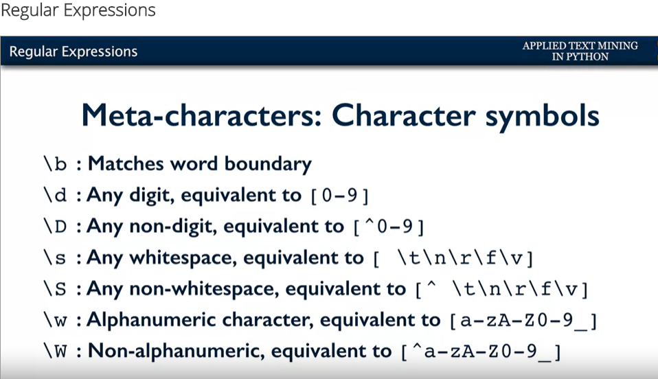

```python
Image('FIG2.PNG', width=500, height=500)
```

[^] ( within [ ] ) is negation in regular expression whereas ^ is "begining of string"

[^a-z] matches any single character that is not from "a" to "z"

^[a-z] means string starts with from "a" to "z"

```python
Video("RegEx.mp4", width=400, height=400)
```

[video not shown]

```python
%%HTML

<div align="middle">
<video width="50%" controls>
      <source src="RegEx.mp4" type="video/mp4">
</video></div>
```

[video not shown]

# Assignment 1

In this assignment, you'll be working with messy medical data and using regex to extract relevant infromation from the data.

Each line of the `dates.txt` file corresponds to a medical note. Each note has a date that needs to be extracted, but each date is encoded in one of many formats.

The goal of this assignment is to correctly identify all of the different date variants encoded in this dataset and to properly normalize and sort the dates.

Here is a list of some of the variants you might encounter in this dataset:

- 04/20/2009; 04/20/09; 4/20/09; 4/3/09
- Mar-20-2009; Mar 20, 2009; March 20, 2009; Mar. 20, 2009; Mar 20 2009;
- 20 Mar 2009; 20 March 2009; 20 Mar. 2009; 20 March, 2009
- Mar 20th, 2009; Mar 21st, 2009; Mar 22nd, 2009
- Feb 2009; Sep 2009; Oct 2010
- 6/2008; 12/2009
- 2009; 2010

Once you have extracted these date patterns from the text, the next step is to sort them in ascending chronological order accoring to the following rules:

- Assume all dates in xx/xx/xx format are mm/dd/yy
- Assume all dates where year is encoded in only two digits are years from the 1900's (e.g. 1/5/89 is January 5th, 1989)
- If the day is missing (e.g. 9/2009), assume it is the first day of the month (e.g. September 1, 2009).
- If the month is missing (e.g. 2010), assume it is the first of January of that year (e.g. January 1, 2010).
- Watch out for potential typos as this is a raw, real-life derived dataset.

With these rules in mind, find the correct date in each note and return a pandas Series in chronological order of the original Series' indices.

For example if the original series was this:

```
0    1999
1    2010
2    1978
3    2015
4    1985
```

Your function should return this:

```
0    2
1    4
2    0
3    1
4    3
```

Your score will be calculated using [Kendall's tau](https://en.wikipedia.org/wiki/Kendall_rank_correlation_coefficient), a correlation measure for ordinal data.

*This function should return a Series of length 500 and dtype int.*

```python
import pandas as pd

doc = []
with open('dates.txt') as file:
    for line in file:
        doc.append(line)

df = pd.Series(doc)
df.iloc[0]
```

```
'03/25/93 Total time of visit (in minutes):\n'
```

```python
pd.set_option('max_colwidth', 200)
pd.set_option('max_rows', 700)
```

```python
df.shape
#df.iloc[0:7]
```

```
(500,)
```

The goal of this assignment is to correctly identify all of the different date variants encoded in this dataset and to properly normalize and sort the dates.

```python
df = pd.DataFrame(df, columns=['Text'])
```

```python
#df.loc[0:100]
```

```python
df_copy = df.copy()
```

## List of variations

04/20/2009; 04/20/09; 4/20/09; 4/3/09

Mar-20-2009; Mar 20, 2009; March 20, 2009; Mar. 20, 2009; Mar 20 2009;

20 Mar 2009; 20 March 2009; 20 Mar. 2009; 20 March, 2009

Mar 20th, 2009; Mar 21st, 2009; Mar 22nd, 2009

Feb 2009; Sep 2009; Oct 2010

6/2008; 12/2009

2009; 2010

### Helper Functions

```python
def removeIdentified(df_original, df_toremove):
    #Each index in created df is a tuple, the first element of this tuple is the index of the original table
    captured_index  = pd.Series([i[0] for i in df_toremove.index])
    print("Number removed: ", captured_index.shape)
    df_original = df_original[~df_original.index.isin(captured_index)]
    print("Number left : " ,df_original.shape)#(379, 2)
    return df_original


def adjustDayMonthYear(df_input):
    if 'Day' not in df_input.columns :
        df_input['Day'] = '01'
    if 'Month' not in df_input.columns:
        df_input['Month'] = '01'
    df_input['Year'].apply(lambda x: "19"+ x if len(x) == 2 else x)
    return df_input

def createFullDate(df_input):
    #Strip Month , year and date off , . -
    transTable = str.maketrans('', '', r',./')
    df_input['Day'] = df_input['Day'].str.translate(transTable)
    df_input['Month'] = df_input['Month'].str.translate(transTable)
    df_input['Year'] = df_input['Year'].str.translate(transTable)
    df_input['FullDate'] = df_input['Year'] +'-' + df_input['Month']+ '-'+df_input['Day']
    df_input['FullDate'] = pd.to_datetime(df_input['FullDate'])
    df_input = df_input[['FullDate', 'Day', 'Month', 'Year']]
    return df_input

def getDFdetails(df_input):
    print(df_input.name)
    print(df_input.shape)
    print(df_input.head())
```

### Procedure 1

Check for dates with all three components

04/20/2009; 04/20/09; 4/20/09; 4/3/09, 1-14-81

```python
df_extract_numerical = df_copy['Text'].str.extractall(r'(?P<FullDate>(?P<Month>\d?\d)[/-](?P<Day>\d?\d)[/-](?P<Year>\d?\d?\d\d))')

#check for year equal to three digits
#df_numerical[(df_numerical['Year'].str.len() == 3)]
#72	1	9/36/308	9	36

# This is the CBC count and so drop these
#df_copy[df_copy['Text'].str.contains('9/36/308')]

#Remove  if dates year is NOT 2 digits or is not 4 digits
df_extract_numerical = df_extract_numerical[(df_extract_numerical['Year'].str.len() == 2) | (df_extract_numerical['Year'].str.len() == 4)]
df_extract_numerical.name = 'df_extract_numerical'
#df_copy.iloc[106]
```

```python
getDFdetails(df_extract_numerical)
```

```
df_extract_numerical
(125, 4)
         FullDate Month Day Year
  match
0 0      03/25/93    03  25   93
1 0       6/18/85     6  18   85
2 0        7/8/71     7   8   71
3 0       9/27/75     9  27   75
4 0        2/6/96     2   6   96
```

Reduce the size of the original dataframe by the identified rows

```python
df_copy = removeIdentified(df_copy,df_extract_numerical)
```

```
Number removed:  (125,)
Number left :  (375, 1)
```

### Procedure 2

Looking for months spelled out

Mar-20-2009; Mar 20, 2009; March 20, 2009; Mar. 20, 2009; Mar 20 2009;

```python
from calendar import month_name

patternlist =  ["(" + a[0:3]+"(" + a[3:] + "|.)?,?)" if len(a) > 3 else a for a in month_name ]
patternlist = patternlist[1:]
totalpattern = "|".join(patternlist)
#print(patternlist)
print(totalpattern)
```

```
(Jan(uary|.)?,?)|(Feb(ruary|.)?,?)|(Mar(ch|.)?,?)|(Apr(il|.)?,?)|May|(Jun(e|.)?,?)|(Jul(y|.)?,?)|(Aug(ust|.)?,?)|(Sep(tember|.)?,?)|(Oct(ober|.)?,?)|(Nov(ember|.)?,?)|(Dec(ember|.)?,?)
```

```python
df_extract_monthname = df_copy['Text'].str.extractall(r'(?P<FullDate>(?P<Month>(Jan(?:uary|.)?,?)|(Feb(?:ruary|.)?,?)|(Mar(?:ch|.)?,?)|(Apr(?:il|.)?,?)|May|(Jun(?:e|.)?,?)|(Jul(?:y|.)?,?)|(Aug(?:ust|.)?,?)|(Sep(?:tember|.)?,?)|(Oct(?:ober|.)?,?)|(Nov(?:ember|.)?,?)|(Dec(?:ember|.)?,?))[\s-](?P<Day>\d?\d),?[\s-](?P<Year>\d\d\d\d))')
df_extract_monthname.name = 'df_extract_monthname'
```

```python
getDFdetails(df_extract_monthname)
```

```
df_extract_monthname
(32, 15)
                    FullDate     Month    2         3    4      5    6    7  \
    match
194 0         April 11, 1990     April  NaN       NaN  NaN  April  NaN  NaN
195 0           May 30, 2001       May  NaN       NaN  NaN    NaN  NaN  NaN
196 0           Feb 18, 1994       Feb  NaN       Feb  NaN    NaN  NaN  NaN
197 0      February 18, 1981  February  NaN  February  NaN    NaN  NaN  NaN
199 0            Jan 24 1986       Jan  Jan       NaN  NaN    NaN  NaN  NaN

             8    9   10   11   12 Day  Year
    match
194 0      NaN  NaN  NaN  NaN  NaN  11  1990
195 0      NaN  NaN  NaN  NaN  NaN  30  2001
196 0      NaN  NaN  NaN  NaN  NaN  18  1994
197 0      NaN  NaN  NaN  NaN  NaN  18  1981
199 0      NaN  NaN  NaN  NaN  NaN  24  1986
```

Reduce the size of the original dataframe by the identified rows

```python
df_copy = removeIdentified(df_copy,df_extract_monthname)
```

```
Number removed:  (32,)
Number left :  (343, 1)
```

### Procedure 3

Retrieve these : 20 Mar 2009; 20 March 2009; 20 Mar. 2009; 20 March, 2009

```python
df_extract_monthname_middle = df_copy['Text'].str.extractall(r'(?P<FullDate>(?P<Day>\d?\d)\s(?P<Month>(Jan(?:uary|.)?,?)|(Feb(?:ruary|.)?,?)|(Mar(?:ch|.)?,?)|(Apr(?:il|.)?,?)|May|(Jun(?:e|.)?,?)|(Jul(?:y|.)?,?)|(Aug(?:ust|.)?,?)|(Sep(?:tember|.)?,?)|(Oct(?:ober|.)?,?)|(Nov(?:ember|.)?,?)|(Dec(?:ember|.)?,?))[\s-](?P<Year>\d\d\d\d))')
df_extract_monthname_middle.name = 'df_extract_monthname_middle'
```

```python
getDFdetails(df_extract_monthname_middle)
```

```
df_extract_monthname_middle
(69, 15)
               FullDate Day Month    3    4    5    6     7    8    9   10  \
    match
125 0       24 Jan 2001  24   Jan  Jan  NaN  NaN  NaN   NaN  NaN  NaN  NaN
126 0       10 Sep 2004  10   Sep  NaN  NaN  NaN  NaN   NaN  NaN  NaN  Sep
127 0       26 May 1982  26   May  NaN  NaN  NaN  NaN   NaN  NaN  NaN  NaN
128 0      28 June 2002  28  June  NaN  NaN  NaN  NaN  June  NaN  NaN  NaN
129 0       06 May 1972  06   May  NaN  NaN  NaN  NaN   NaN  NaN  NaN  NaN

            11   12   13  Year
    match
125 0      NaN  NaN  NaN  2001
126 0      NaN  NaN  NaN  2004
127 0      NaN  NaN  NaN  1982
128 0      NaN  NaN  NaN  2002
129 0      NaN  NaN  NaN  1972
```

Reduce the size of the original dataframe by the identified rows

```python
df_copy = removeIdentified(df_copy,df_extract_monthname_middle)
```

```
Number removed:  (69,)
Number left :  (274, 1)
```

### Procedure 4

Mar 20th, 2009; Mar 21st, 2009; Mar 22nd, 2009

```python
# print(df_copy[df_copy['Text'].str.contains('\d?\dth', regex=True)])
# print(df_copy[df_copy['Text'].str.contains('\d?\dst', regex=True)])
# print(df_copy[df_copy['Text'].str.contains('\d?\dth', regex=True)])

# pd.set_option('max_colwidth', 1000)
```

```python
df_extract_datequalifier = df_copy['Text'].str.extractall(r'(?P<FullDate>(?P<Month>(Jan(?:uary|.)?,?)|(Feb(?:ruary|.)?,?)|(Mar(?:ch|.)?,?)|(Apr(?:il|.)?,?)|May|(Jun(?:e|.)?,?)|(Jul(?:y|.)?,?)|(Aug(?:ust|.)?,?)|(Sep(?:tember|.)?,?)|(Oct(?:ober|.)?,?)|(Nov(?:ember|.)?,?)|(Dec(?:ember|.)?,?))\s(?P<Day>\d?\d(?:nd|st|th|rd),)\s(?P<Year>\d\d\d\d))')
df_extract_datequalifier.name = 'df_extract_datequalifier'
```

```python
getDFdetails(df_extract_datequalifier)
```

```
df_extract_datequalifier
(0, 15)
Empty DataFrame
Columns: [FullDate, Month, 2, 3, 4, 5, 6, 7, 8, 9, 10, 11, 12, Day, Year]
Index: []
```

Reduce the size of the original dataframe by the identified rows

```python
#df_copy = removeIdentified(df_copy,df_datequalifier)
```

### Procedure 5

Check for dates with only two of the three components

Feb 2009; Sep 2009; Oct 2010

```python
df_copy.shape
```

```
(274, 1)
```

```python
df_extract_monthyear = df_copy['Text'].str.extractall(r'(?P<FullDate>(?P<Month>Jan\s|Feb\s|Mar\s|Apr\s|May\s|Jun\s|Jul\s|Aug\s|Sep\s|Oct\s|Nov\s|Dec\s)(?P<Year>\d\d\d\d))')
df_extract_monthyear.name = 'df_extract_monthyear'
```

```python
getDFdetails(df_extract_monthyear)
```

```
df_extract_monthyear
(47, 3)
           FullDate Month  Year
    match
230 0      May 1986  May   1986
231 0      May 2016  May   2016
234 0      Jul 2003  Jul   2003
235 0      Oct 2015  Oct   2015
236 0      May 1995  May   1995
```

Reduce the size of the original dataframe by the identified rows

```python
df_copy = removeIdentified(df_copy,df_extract_monthyear)
```

```
Number removed:  (47,)
Number left :  (227, 1)
```

### Procedure 6

Check for dates with only two of the three components

6/2008; 12/2009

Does not start with one or two digits, but has month with one or two digits and years with four digits

```python
df_extract_numerical_month_year = df_copy['Text'].str.extractall(r'(?P<FullDate>(?P<Month>\b\d?\d)\/(?P<Year>\d\d\d\d)\b)')
df_extract_numerical_month_year.name = 'df_extract_numerical_month_year'
```

```python
getDFdetails(df_extract_numerical_month_year)
```

```
df_extract_numerical_month_year
(110, 3)
          FullDate Month  Year
    match
343 0       6/1998     6  1998
344 0       6/2005     6  2005
345 0      10/1973    10  1973
346 0       9/2005     9  2005
347 0      03/1980    03  1980
```

Reduce the size of the original dataframe by the identified rows

```python
df_copy = removeIdentified(df_copy,df_extract_numerical_month_year)
```

```
Number removed:  (110,)
Number left :  (117, 1)
```

### Procedure 7

Check for dates with only year

2008; 2009

Word boundary followed by year

```python
df_extract_just_year = df_copy['Text'].str.extractall(r'(?P<Year>\d{4,4})[^\d]?')
df_extract_just_year = df_extract_just_year[df_extract_just_year['Year'] < '3000']
df_extract_just_year.name = 'df_extract_just_year'
getDFdetails(df_extract_just_year)
```

```
df_extract_just_year
(117, 1)
           Year
    match
198 0      2013
227 0      2011
228 0      1985
229 0      2011
232 0      1977
```

Reduce the size of the original dataframe by the identified rows

```python
df_copy = removeIdentified(df_copy,df_extract_just_year)
```

```
Number removed:  (117,)
Number left :  (0, 1)
```

```python
listDF = %who_ls DataFrame
#Get the list of dataframe create and clean them up
names = [dfName for dfName in listDF if "extract" in dfName]
print(names)

df_extract_just_year = adjustDayMonthYear(df_extract_just_year)
df_extract_monthname= adjustDayMonthYear(df_extract_monthname)
df_extract_monthname_middle = adjustDayMonthYear(df_extract_monthname_middle)
df_extract_monthyear = adjustDayMonthYear(df_extract_monthyear)
df_extract_numerical= adjustDayMonthYear(df_extract_numerical)
df_extract_numerical_month_year = adjustDayMonthYear(df_extract_numerical_month_year)

df_extract_just_year = createFullDate(df_extract_just_year)
df_extract_monthname = createFullDate(df_extract_monthname)
df_extract_monthname_middle = createFullDate(df_extract_monthname_middle)
df_extract_monthyear = createFullDate(df_extract_monthyear)
df_extract_numerical = createFullDate(df_extract_numerical)
df_extract_numerical_month_year = createFullDate(df_extract_numerical_month_year)
```

```
['df_extract_datequalifier', 'df_extract_just_year', 'df_extract_monthname', 'df_extract_monthname_middle', 'df_extract_monthyear', 'df_extract_numerical', 'df_extract_numerical_month_year']
```

```python
#Alternative to removing each dataframe from original
#output = output.append(df5[~df5.level_0.isin(output.level_0)])


new_df = pd.concat([df_extract_just_year, df_extract_monthname, df_extract_monthname_middle, df_extract_monthyear, df_extract_numerical, df_extract_numerical_month_year])

new_df.sort_index(inplace=True)

new_df1 = new_df.reset_index()
new_df1 = new_df1.sort_values(["FullDate", "level_0"]).reset_index(drop=True)
```

## FINAL ANSWER

```python
#FINAL ANSWER
new_df1.level_0.head()
```

```
0     9
1    84
2     2
3    53
4    28
Name: level_0, dtype: int64
```

# Exercises from the Course

```python
import pandas as pd

time_sentences = ["Monday: The doctor's appointment is at 2:45pm.",
                  "Tuesday: The dentist's appointment is at 11:30 am.",
                  "Wednesday: At 7:00pm, there is a basketball game!",
                  "Thursday: Be back home by 11:15 pm at the latest.",
                  "Friday: Take the train at 08:10 am, arrive at 09:00am."]

df = pd.DataFrame(time_sentences, columns=['text'])
df
```

#### Find the number of characters for each string in df['text']

```python
df = df.assign(text_length = df['text'].apply(len))
```

#### Find the number of tokens for each string in df['text']

```python
# df.assign(split_text = df['text'].str.split())
df_expanded = df['text'].str.split(expand=True)

df_expanded
```

#### Find which entries contain the word 'appointment'

```python
df = df.assign(text_contains_appointment = df['text'].str.contains('appointment'))
```

#### Find how many times a digit occurs in each string

##### Two methods shown - One gets the count of digits and the other uses a powerful function "enumerate" to loop through the string . It allows us to loop over something and have an automatic counter.

```python
df = df.assign(contains_digits = df['text'].str.count(r'\d'))
```

```python
def indexOfDigit(text):
    return ({c: i  for i, c in enumerate(text) if c.isdigit()})

df['text'].apply(indexOfDigit)
```

#### Find all occurances of the digits

```python
df['text'].str.findall(r'\d')
```

```python
Image('FIG3.png', width=400, height=400)
```

[output not shown]

```python
# group and find the hours and minutes
df['text'].str.findall(r'(\d?\d):(\d?\d)')
```

```python
# replace weekdays with '???'
df['text'].str.replace(r'\w+day\b', '???')
```

```python
# replace weekdays with 3 letter abbrevations
df['text'].str.replace(r'(\w+day\b)', lambda x: x.groups()[0][:3])
```

```python
# create new columns from first match of extracted groups
df['text'].str.extract(r'(\d?\d):(\d\d)')
```

```python
# extract the entire time, the hours, the minutes, and the period
df['text'].str.extractall(r'((\d?\d):(\d\d) ?([ap]m))')
```

```python
# extract the entire time, the hours, the minutes, and the period with group names
df['text'].str.extractall(r'(?P<time>(?P<hour>\d?\d):(?P<minute>\d\d) ?(?P<period>[ap]m))')
```

Adding a new cell